# Ford GoBike

## by : Said Fawzy Mohammed Huda

## Investigation Overview

> - In the following Slides we will go through data of GoBike System Data.
> - The Data includes information about individual rides made in a bike-sharing system covering the greater San Francisco Bay area.
> - We will try to explore what affects the Number of rides :

## Dataset Overview

> - We have a data set of 16 fields of features that records rides.
> - We have 183,412 records
> - After data wrangeling we have new dataset of **19** fields and **174,952** records

## the main features of interest in the dataset :

> We will be interested in :
> - The Number of rides ,and if the time or type of user affect
> - The duration of ride and if it is affected by user type or gender

### Features in the dataset that will help in investigation

> Those features will help us investigate :
> - The week day of the ride
> - Month of the ride
> - Ride Duration
> - The Age of the member
> - The Gender of the member
> - The user type (customer of subscriber).

## The Day of the Week

> **Dose The day of the Week affects No. of rides?**

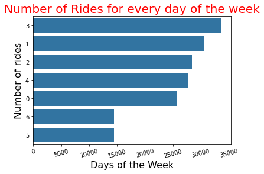

# The Member Gender

> Does the gender of the member affect the No. of rides ?

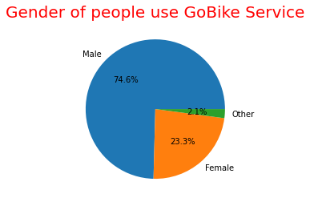

> For The **Gender** Variable:
> - We found that most people use the service were male.

# The User Type

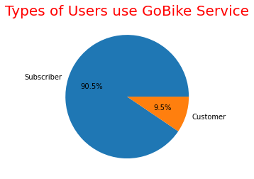

> For the **Type of user** variable:
> - We found that most people use the service are **Subscribers**

# The Age

> Does the age of the user affect the Number of rides ?

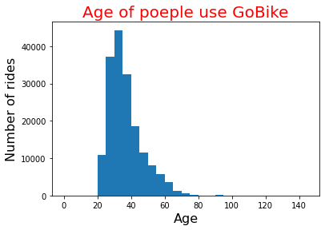

> For **Age** Variable:
> - We found that most people use the services were in age between **25 Abd 40** , which was expected

# The Ride Duration

> Dose the ride duration affect the Number of rides?

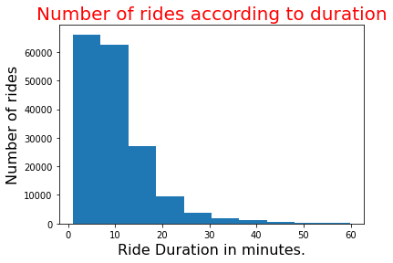

> For **duration** Variable:
> - We found that most ride durations were less than 10 min , which is expected for a bike ride

# ٌRelationship between Age and Ride Duration

> Is there a relation between the duration of the ride , and the age of the member.

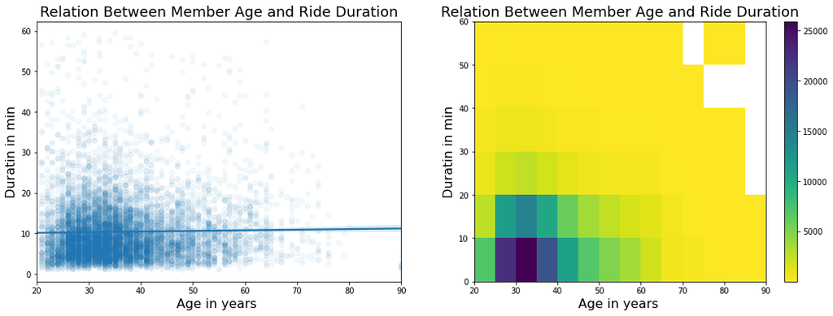

> - Most people use the service are young (less than 40 year old),mostly between 25-40 year old
> - Most rides are less than 10 minutes.
> - There is no clear indication that there is a relation between member age and the duration of his/ride

# Relation Between Gender and Ride Duration

> Is there relation between the distribution of ride duration and the gender of the member ?

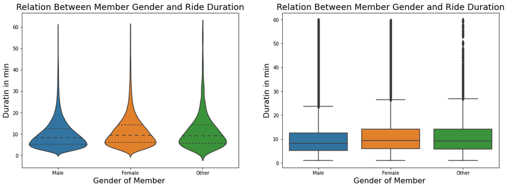

> - There is no effect of gender in the distribution of the ride duration
> - The three gender types have nearly the same distribution.
> - Male may have more slightly less median and disruption of the other two types
> - That mean that male duration has slightly less in average of the other two types

# Relationship Between Type of users and durations

> Let us see if there is relation between the type of users and the duration

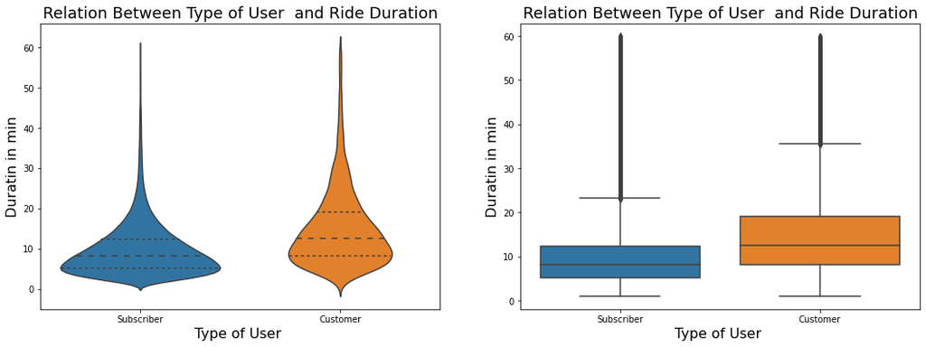

> Although as we saw before that number of customer is only 9.5 % of all users , they are more distributed and have more average duration than the Subscribers that represents 90.5 %.

# Realationship between Type of User and the User Gender

> Let us see how is the distripution of user type according to gender

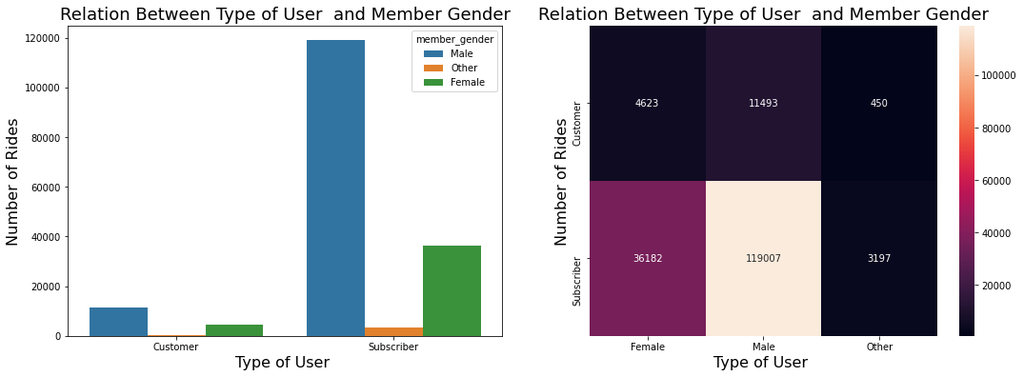

> - **Male** are most people in Subscriber and Customer Users.
> - Male Subscribers are 119K compared to only 11K for Male Customers.
> - Female Subscribers are 36K compared to only 4k for female customers.
> - Other gender Subscribers are 3K compared to only 450 of other customers

# Relationship Between Age , Duration and Gender

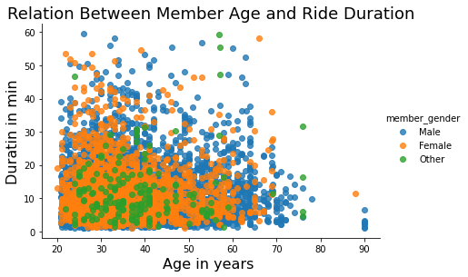

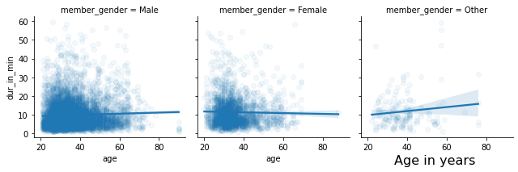

# Relationship Between Age , Duration and User Type

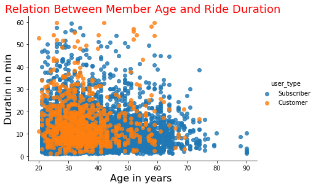

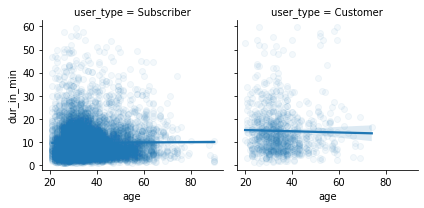